# OSNOVE PROGRAMSKOG JEZIKA R

#### Spremanje slike u datoteku

Za kraj ovog dijela naučimo spremiti sliku u datoteku kako bi ju mogli lako ugraditi u neki drugi izvještajni dokument, znanstveni rad, proslijediti elektroničkom poštom i sl.

R po default-u koristi zaslon kao “grafički uređaj” (engl. graphical device). Opcionalno, grafiku možemo “preusmjeriti” na neki drugi “uređaj”, najčešće datoteku određenog tipa (`png`, `tiff`, `pdf` i sl.). Popis svih mogućnosti možemo pogledati uz pomoć naredbe ?Devices. Za spremanje grafova u rasterskom formatu preporučuju se `png` i `tiff` formati, dok je za vektorski format uobičajeno koristiti `pdf`.

Spremanje grafova može se obaviti pozivom funkcije koja odgovara formatu u kojeg želimo pohraniti sliku (npr. funkcija `pdf` spremiti će *iduću* sliku u *pdf datoteku), no paket `ggplot2` nudi nešto praktičniji način - funkcija `ggsave` pohraniti će* zadnje iscrtani* graf u datoteku odabranog imena, pri čemu će format slike zaključiti sama iz ekstenzije datoteke koju odaberemo. Ovaj način je bolji utoliko što imamo šansu prvo vidjeti graf i tek onda se odlučiti na pohranu.

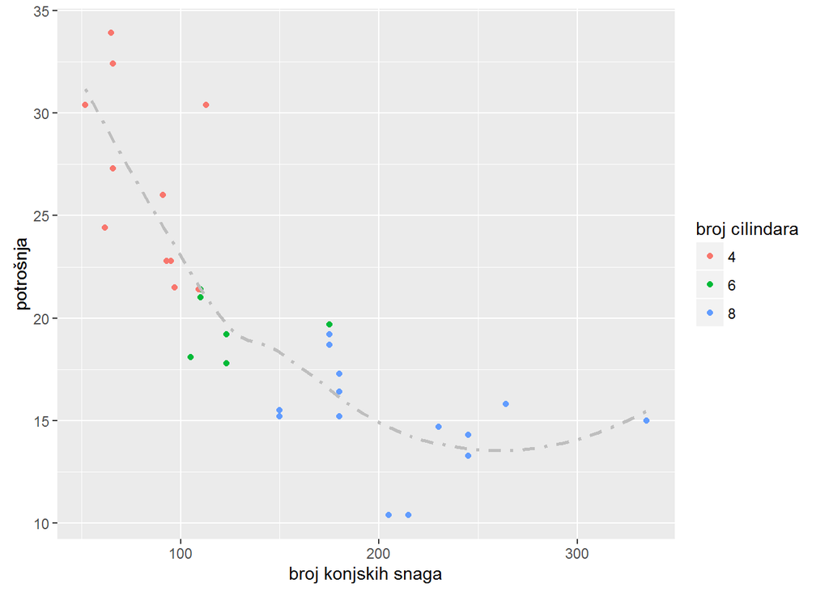

```r
# spremite sljedeći graf u datoteke `figure1.pdf`i `figure1.png`
ggplot(mtcars, aes(x = hp, y = mpg, col = as.factor(cyl))) + geom_point() +
geom_smooth(aes(x = hp, y = mpg), method = 'loess', linetype = 4, color = "grey", se = F, inherit.aes = F) +
labs(x = "broj konjskih snaga", y = "potrošnja", col = "broj cilindara")
```

```r
ggsave("figure1.pdf")
ggsave("figure1.png")
```

## Zadaci za vježbu

Za sljedeće zadatke učitajte i proučite podatkovni skup mpg koji dolazi zajedno s paketom ggplot2.